# Step 1 – Preparing the EMA Dataset (Tutorial Final, Extended + Inputs)

Stefan Schneider

# Overview

This notebook illustrates **Step 1** of the *EMAauxiliary Workflow*: how to prepare an EMA dataset so that every scheduled prompt—completed or missed— appears in the data and is accompanied by auxiliary information.

Each section is independent and can be adapted to your own data. Code chunks are annotated with **User inputs** and **New variables created**.

```r
library(dplyr)
library(tidyr)
library(ggplot2)
library(lubridate)
library(plotly)
library(data.table)
library(purrr)
set.seed(1234)
```

# Part 0, Option A: Simulate Example Data (skip if using your own)

Creates a runnable toy dataset for demonstration.

```r
simulate_ema_data <- function(
  n_id = 10, n_day = 3, n_prom = 6,
  mean_mood = 50, mean_stress = 50,
  sd_within = 10, missing_rate = 0.3,
  seed = 1234
) {

  set.seed(seed)

  # ---- FULL GRID OF PROMPTS ----
  full <- expand.grid(
    id           = 1:n_id,
    day          = 1:n_day,
    daily_prompt = 1:n_prom
  )

  # ---- GLOBAL CONSECUTIVE COUNTER ----
  # beep_num counts across ALL days for each participant
  full <- full %>%
    arrange(id, day, daily_prompt) %>%
    group_by(id) %>%
    mutate(prompt_num = row_number()) %>%
    ungroup()

  # ---- PERSON-LEVEL VARIABLES ----
  person_df <- data.frame(
    id     = 1:n_id,
    age    = sample(40:70, n_id, replace = TRUE),
    gender = sample(c(1:2), n_id, replace = TRUE)
  )

  df <- dplyr::left_join(full, person_df, by = "id")

  # ---- SIMULATE LEVEL-1 VARIABLES ----
  df <- df %>%
    dplyr::group_by(id) %>%
    dplyr::mutate(
      mood   = mean_mood   + arima.sim(model = list(ar = 0.4), n = n()) * sd_within,
      stress = mean_stress + arima.sim(model = list(ar = 0.3), n = n()) * sd_within
    ) %>%
    dplyr::ungroup()

  # ---- INTRODUCE MISSING PROMPTS ----
  df <- df %>%
    dplyr::group_by(id, day) %>%
    dplyr::sample_frac(1 - missing_rate) %>%  # roughly 30% missing per day
    dplyr::arrange(id, day, daily_prompt) %>%
    dplyr::ungroup()

  # ---- ADD DETERMINISTIC TIMESTAMPS ----
  df <- df %>%
    mutate(
      datetime = make_datetime(
        year  = 2023,
        month = 1,
        day   = day,
        hour  = 8 + 2 * (daily_prompt - 1)
      )
    )

  return(df)
}

# Generate a test dataset
ema_df <- simulate_ema_data(n_id = 5, n_day = 3, n_prom = 6, missing_rate = 0.3)
head(ema_df)
```

```
## # A tibble: 6 × 9
##      id   day daily_prompt prompt_num   age gender  mood stress
##   <int> <int>        <int>      <int> <int>  <int> <dbl>  <dbl>
## 1     1     1            2          2    67      2  57.7   60.1
## 2     1     1            3          3    67      2  52.0   51.9
## 3     1     1            4          4    67      2  45.7   55.7
## 4     1     1            6          6    67      2  37.3   68.3
## 5     1     2            2          8    67      2  59.0   57.5
## 6     1     2            3          9    67      2  48.7   55.7
## # ℹ 1 more variable: datetime <dttm>
```

#Part 0, Option A (continued): Simulate Demographics Data (skip if using your own)

```r
# Simulated person-level demographics (BLIMP-friendly: numeric only)
simulate_demog_data <- function(n_id = 10, seed = 1234) {
  set.seed(seed)

  tibble(
    id = 1:n_id,

    # Education coded 1–4
    # 1 = High school
    # 2 = Some college
    # 3 = Bachelor's
    # 4 = Graduate degree
    education = sample(
      1:4, n_id, replace = TRUE,
      prob = c(0.25, 0.30, 0.30, 0.15)
    ),

    # Income bracket coded 1–4
    # 1 = <$30k
    # 2 = $30–60k
    # 3 = $60–100k
    # 4 = $100k+
    income_bracket = sample(
      1:4, n_id, replace = TRUE,
      prob = c(0.30, 0.30, 0.25, 0.15)
    )
  )
}


# Generate demographics dataset
demog_df <- simulate_demog_data(n_id = 5)
head(demog_df)
```

```
## # A tibble: 5 × 3
##      id education income_bracket
##   <int>     <int>          <int>
## 1     1         2              3
## 2     2         1              1
## 3     3         1              1
## 4     4         1              3
## 5     5         4              2
```

# Part 0, Option B: Load your own data

If you have your own EMA dataset, start here.  
Otherwise, use the simulated data above to follow along.

```r
head(ema_df)
```

```
## # A tibble: 6 × 9
##      id   day daily_prompt prompt_num   age gender  mood stress
##   <int> <int>        <int>      <int> <int>  <int> <dbl>  <dbl>
## 1     1     1            2          2    67      2  57.7   60.1
## 2     1     1            3          3    67      2  52.0   51.9
## 3     1     1            4          4    67      2  45.7   55.7
## 4     1     1            6          6    67      2  37.3   68.3
## 5     1     2            2          8    67      2  59.0   57.5
## 6     1     2            3          9    67      2  48.7   55.7
## # ℹ 1 more variable: datetime <dttm>
```

#Part 0, Option B (continued): Standardize key variable names (highly recommended)

To ensure that all tutorial code runs smoothly, rename your EMA variables so that they use the following standard names:

Required: - `id` = participant identifier

Then your dataset must have **either**: - `day` + `daily_prompt` (prompt number within day)

**OR** - `prompt_num` (global running counter across study)

**Optional (if available)**: - You may also include all four (`id`, `day`, `daily_prompt`, `prompt_num`) if your dataset records both within-day and global numbering.

## How to rename your variables

Rename only the variables that actually exist in your dataset.

Example:

```r
ema_df <- ema_df %>%
  rename(
    id           = participant_id,    # replace with your ID variable
    day          = study_day,         # replace only if you have a day variable
    daily_prompt = beep_of_the_day,   # replace only if you have within-day prompts
    prompt_num   = running_beep,      # replace only if you have a global counter
    datetime     = prompt_datetime    # replace only if you have a full date–time of each prompt (POSIXct; e.g., "2023-01-03 14:00:00")
  )
```

## Note on datetime:

The datetime variable must be a full date–time stamp (including both date and time), ideally stored as a POSIXct object. If your data include only time-of-day (e.g., “14:00”) without a date, you will need to combine it with a (real of fake) study day or calendar date before using Options 2 or 3 below.

Example: constructing datetime from day + time-of-day

```r
ema_df <- ema_df %>%
  mutate(
    datetime = lubridate::make_datetime(
      year  = 2023,
      month = 1,
      day   = day,
      hour  = time_of_day_hours
    )
  )
```

# Part 1 Add Rows for Missed Prompts

Reinsert skipped prompts so that each person / day has a complete sequence.

⚠️ **Note.** The exact procedure for reinserting skipped prompts will depend on your EMA design and available data structure.  
The code examples below are intended as **starting points** that you can adapt for your own dataset.  
Depending on whether your study used fixed, semi-random, or fully random prompt schedules—and on what information your EMA platform provides—you may need to modify one or more of these steps to match your data.

# Part 1, Option 1: assumes that the dataset includes a variable indicating the prompt numbers as ORIGINALLY SCHEDULED

This option automatically adds rows for all skipped EMA prompts as long as your dataset contains a variable that numbers prompts in order. This may be either:

- per-day numbering, e.g. id = 27, day = 3, daily_prompt = 1,2,3,4,5,6
- global consecutive numbering, e.g. id = 27, prompt_num = 1…84 across all days

The code below detects which structure the dataset has and inserts rows for any missing prompt numbers within the appropriate grouping (either id + day or id only).

### **User inputs**

Adjust the name for the id variable if necessary Adjust the name for the day variable if necessary or set to NA if you have global consecutive ordering Adjust the name of the prompt counter variable if necessary

### **New variable created**

- missed_prompt (0/1): 0 = originally observed prompt, 1 = prompt inserted because it was missing

```r
# ---- USER INPUTS ----
day_var    <- "day"            # set to NA if no day variable exists
prompt_var <- "daily_prompt"   # OR "prompt_num" if using a global counter
# ----------------------

# ---- Validate prompt counter ----
if (!prompt_var %in% names(ema_df)) {
  stop(paste0("Prompt variable '", prompt_var, "' not found in data."))
}

# ---- Decide grouping structure ----
if (!is.na(day_var) && day_var %in% names(ema_df)) {
  group_vars <- c("id", day_var)
  message("Using per-day prompt structure (id + day).")
} else {
  group_vars <- "id"
  message("Using global prompt structure (id only).")
}
```

```
## Using per-day prompt structure (id + day).
```

```r
# ---- Determine expected number of prompts ----
expected_prompts <- ema_df %>%
  summarise(n_prom = max(.data[[prompt_var]], na.rm = TRUE)) %>%
  pull(n_prom)

# ---- Mark originally observed rows (structural flag) ----
ema_df <- ema_df %>%
  mutate(observed_prompt = 1L)

# ---- Insert missing prompt rows ----
ema_df <- ema_df %>%
  group_by(across(all_of(group_vars))) %>%
  tidyr::complete(!!sym(prompt_var) := seq_len(expected_prompts)) %>%
  ungroup()

# ---- If day exists, create global prompt_num ----
if (!is.na(day_var) && day_var %in% names(ema_df)) {
  ema_df <- ema_df %>%
    mutate(
      prompt_num =
        (.data[[day_var]] - 1L) * expected_prompts +
        .data[[prompt_var]]
    )
}

# ---- Structural identification of missed prompts ----
ema_df <- ema_df %>%
  mutate(
    missed_prompt = if_else(is.na(observed_prompt), 1L, 0L)
  ) %>%
  select(-observed_prompt)   # remove helper column

# ---- Summary table (QA check) ----
ema_df %>% count(across(all_of(group_vars)), missed_prompt)
```

```
## # A tibble: 30 × 4
##       id   day missed_prompt     n
##    <int> <int>         <int> <int>
##  1     1     1             0     4
##  2     1     1             1     2
##  3     1     2             0     4
##  4     1     2             1     2
##  5     1     3             0     4
##  6     1     3             1     2
##  7     2     1             0     4
##  8     2     1             1     2
##  9     2     2             0     4
## 10     2     2             1     2
## # ℹ 20 more rows
```

# Part 1, Option 2: assumes the EMA prompts were administered on a FIXED SCHEDULE.

Irregular Schedules (datetime expansion): For fixed schedules with known expected times, reconstruct the full datetime grid.

### **User inputs**

- `expected_times_per_day`: vector of expected hours for prompts (length = prompts/day).

### **New variables created**

- `datetime`: POSIXct timestamp for each expected prompt.
- `missed_prompt` (0/1): re-derived based on whether a response exists at that expected time.

```r
expected_times_per_day <- c(8, 10, 12, 14, 16, 18)

# Create a synthetic datetime if none exists (demo-only fallback)
if (!"datetime" %in% names(ema_df)) {

  if ("daily_prompt" %in% names(ema_df) && "day" %in% names(ema_df)) {
    # Use daily_prompt (within-day index) + expected_times_per_day
    ema_df <- ema_df %>%
      mutate(datetime = make_datetime(
        year = 2023, month = 1, day = day,
        hour = expected_times_per_day[daily_prompt]
      ))
    message("No datetime column found — created synthetic timestamps using day + daily_prompt + expected_times_per_day.")

  } else {
    stop("No datetime column found. To use Option 2, you need either (a) an existing datetime column, or (b) day + daily_prompt so we can construct datetime from expected_times_per_day.")
  }
}

# tag observed rows
ema_df <- ema_df %>% mutate(observed_prompt = 1L)

expected_grid <- ema_df %>%
  distinct(id, day) %>%
  mutate(expected_datetime =
           purrr::map(day, ~make_datetime(year = 2023, month = 1, day = .x,
                                          hour = expected_times_per_day))) %>%
  unnest(expected_datetime)

ema_df <- expected_grid %>%
  left_join(ema_df, by = c("id", "day", "expected_datetime" = "datetime")) %>%
  rename(datetime = expected_datetime) %>%
  mutate(missed_prompt = if_else(is.na(observed_prompt), 1L, 0L)) %>%
  select(-observed_prompt)
```

# Part 1, Option 3) Handling Random or Semi-Random EMA Schedules (Reconstructing Expected Prompts)

### Case 1 – Scheduled times available

Merge a **complete schedule** with **completed responses**.

### **User inputs**

- `scheduled_df`: dataset with all scheduled prompts (`id`, `day`, `scheduled_time`)
- `completed_df`: dataset with completed prompts (`id`, `day`, `response_time`, survey variables…)
- Column mapping for the join: `scheduled_time` ↔︎ `response_time`

### **New variables created**

- `datetime`: scheduled timestamp for each prompt
- `missed_prompt` (0/1): 1 if no response was recorded for that scheduled time

```r
# Example dummy data for demonstration
scheduled_df <- expand.grid(
  id = 1:2,
  day = 1:2,
  scheduled_time = make_datetime(2023, 1, 1, c(8, 10, 12, 14, 16, 18))
)

completed_df <- scheduled_df %>%
  filter(!(id == 1 & day == 1 & lubridate::hour(scheduled_time) == 12)) %>%  # simulate a missed prompt
  mutate(response_time = scheduled_time,
         mood = rnorm(n(), 50, 10),
         stress = rnorm(n(), 50, 10))

###end of creating data for demonstration

completed_df <- completed_df %>% mutate(observed_prompt = 1L)

ema_df <- scheduled_df %>%
  left_join(completed_df, by = c("id", "day", "scheduled_time" = "response_time")) %>%
  rename(datetime = scheduled_time) %>%
  mutate(missed_prompt = if_else(is.na(observed_prompt), 1L, 0L)) %>%
  select(-observed_prompt)
```

### Case 2 – Scheduled times not available, but number of prompts per day known

Reconstruct plausible expected prompts using **median observed times** per prompt-slot.

**⚠️ Important: Design Assumptions** This reconstruction assumes relatively stable prompt timing. It may be inappropriate for studies with flexible schedules, overlapping response windows, shift work, or time zone changes. In such cases, reconstructed prompts may be inaccurate.  
**Please adapt this step to your EMA design.**

This section reconstructs likely expected prompt times based on the median timing of observed prompts, assuming a fixed number of daily prompts for each participant.

### **User inputs**

- `n_prompts_per_day`: fixed number of prompts per day
- `time_window_start`, `time_window_end`: first/last hour of the daily sampling window
- Optional: `anchor_year`, `anchor_month` for constructing POSIXct times

### **New variables created**

- `prompt_slot` (1…n): position of the expected prompt within the day
- `expected_datetime`: reconstructed timestamp for each expected prompt
- `missed_prompt` (0/1): 1 if no response observed in that slot

⚠️ **Review the design assumptions above before running this step.**

```r
n_prompts_per_day <- 6     # number of prompts per day
time_window_start <- 8     # first prompt window start hour (e.g., 8 AM)
time_window_end   <- 20    # last prompt window end hour (e.g., 8 PM)

# ---- 0) Structural flag: mark originally observed rows ----
ema_df <- ema_df %>%
  dplyr::mutate(observed_prompt = 1L)

# ---- 1) Create / identify a within-day prompt slot for median-time estimation ----
# Prefer daily_prompt if it exists; otherwise derive prompt_slot from global prompt_num
if ("daily_prompt" %in% names(ema_df)) {
  ema_df <- ema_df %>% dplyr::mutate(prompt_slot = daily_prompt)
} else if ("prompt_num" %in% names(ema_df)) {
  # Assumes fixed n_prompts_per_day and that prompt_num is consecutive within person across days
  ema_df <- ema_df %>%
    dplyr::mutate(prompt_slot = ((prompt_num - 1L) %% n_prompts_per_day) + 1L)
} else {
  stop("Case 2 requires either 'daily_prompt' or 'prompt_num' to construct prompt slots.")
}

# ---- 2) Median observed hour for each prompt slot ----
observed_times <- ema_df %>%
  dplyr::mutate(hour = lubridate::hour(datetime)) %>%
  dplyr::group_by(prompt_slot) %>%
  dplyr::summarise(median_hour = median(hour, na.rm = TRUE), .groups = "drop")

# If any slots are missing, fill with evenly spaced hours across window
if (nrow(observed_times) < n_prompts_per_day || any(is.na(observed_times$median_hour))) {
  observed_times <- tibble::tibble(
    prompt_slot = seq_len(n_prompts_per_day),
    median_hour = seq(time_window_start, time_window_end, length.out = n_prompts_per_day)
  )
}

# ---- 3) Build full expected grid: every id/day × prompt_slot ----
expected_grid <- ema_df %>%
  dplyr::distinct(id, day) %>%
  tidyr::expand_grid(prompt_slot = seq_len(n_prompts_per_day)) %>%
  dplyr::mutate(
    expected_datetime = lubridate::make_datetime(
      year = 2023, month = 1, day = day,
      hour = observed_times$median_hour[prompt_slot]
    )
  )

# ---- 4) Merge expected grid to observed EMA data (structural identification of missing prompts) ----
ema_df <- expected_grid %>%
  dplyr::left_join(
    ema_df %>% dplyr::select(-dplyr::any_of(c("prompt_slot"))),
    by = c("id", "day", "expected_datetime" = "datetime")
  ) %>%
  dplyr::rename(datetime = expected_datetime) %>%
  dplyr::mutate(
    missed_prompt = dplyr::if_else(is.na(observed_prompt), 1L, 0L),
    prompt_num    = prompt_slot   # optional: treat slot as per-day prompt index after reconstruction
  ) %>%
  dplyr::select(-observed_prompt)  # drop helper flag

# ---- 5) Quick check ----
ema_df %>%
  dplyr::group_by(id, day) %>%
  dplyr::summarise(
    total_prompts = dplyr::n(),
    missed        = sum(missed_prompt),
    .groups       = "drop"
  )
```

# Part 2 Fill Person-Level (Level 2) Variables

EMA analyses often require person-level (between-person) variables such as age, gender, education, or clinical characteristics. These variables must be present on **every EMA row**, including rows inserted for missed prompts.

There are two common scenarios:

## **Scenario A: Person-level variables already appear in the EMA dataset**

In this case, the newly inserted rows from Step 1 will have `NA` for these variables.  
We fill them using `tidyr::fill()`.

### **User inputs**

- `level2_vars`: names of variables that are constant within participant

### **New variables created**

- none — the function fills in existing columns

```r
level2_vars <- c("age","gender")

ema_df <- ema_df %>%
  group_by(id) %>%
  tidyr::fill(all_of(level2_vars), .direction="downup") %>%
  ungroup()
```

## **Scenario B: Person-level variables are stored in a separate dataset**

If demographics or baseline variables are stored externally (e.g., in a separate demographics file), merge them after Step 1 (after missing rows are created) so that demographic variables populate both observed and reconstructed prompts.

### **User inputs**

- demog_df: dataset containing one row per participant
- level2_vars: the person-level variables from the demographics file
- Note: Demographics dataset must include an id column matching the EMA dataset

### **New variables created***

- person-level variables appended via merge

```r
# Example:
# demog_df has columns: id, education, income

ema_df <- left_join(ema_df, demog_df, by = "id")

# Optionally fill, in case the demographics file contains NAs
level2_vars <- c("education", "income_bracket")

ema_df <- ema_df %>%
  group_by(id) %>%
  tidyr::fill(all_of(level2_vars), .direction = "downup") %>%
  ungroup()
```

# Part 3 Create Lagged Variables

### **User inputs**

- `vars_to_lag`: variables to lag
- `max_lag`: maximum lag order

### **New variables created**

- `variable_lag1`, `variable_lag2`, …: lagged versions up to `max_lag`

```r
vars_to_lag <- c("missed_prompt", "mood","stress")
max_lag <- 1

for(lag in 1:max_lag){
  ema_df <- ema_df %>%
    group_by(id) %>%
    mutate(across(all_of(vars_to_lag),
                  ~dplyr::lag(.x, lag),
                  .names="{.col}_lag{lag}")) %>%
    ungroup()
}
```

# Part 4 Create Individual SD (iSD) Variables

### **User inputs**

- `vars_for_iSD`: variables for which to compute iSD

### **New variables created**

- `variable_iSD`: per-person SD

```r
vars_for_iSD <- c("mood","stress")

iSD_df <- ema_df %>%
  group_by(id) %>%
  summarise(across(all_of(vars_for_iSD),
                   ~sd(.x, na.rm=TRUE),
                   .names="{.col}_iSD"),
            .groups="drop")

ema_df <- left_join(ema_df, iSD_df, by="id")
```

# Part 5 Diagnostics and QA Visualizations

Together, these QA steps allow you to sanity-check the integrity of the reconstructed dataset before you proceed to Step 2 (evaluating auxiliary variables) or Step 3 (model fitting). If something looks off during this stage—such as too many red cells or the wrong number of prompts per day—it’s a sign to revisit Step 1 before moving forward.

```r
compliance <- ema_df %>%
  group_by(id) %>%
  summarise(prompts_total = n(),
            prompts_missed = sum(missed_prompt),
            compliance = 1 - prompts_missed / prompts_total)

print(compliance)
```

```
## # A tibble: 5 × 4
##      id prompts_total prompts_missed compliance
##   <int>         <int>          <int>      <dbl>
## 1     1            18              6      0.667
## 2     2            18              6      0.667
## 3     3            18              6      0.667
## 4     4            18              6      0.667
## 5     5            18              6      0.667
```

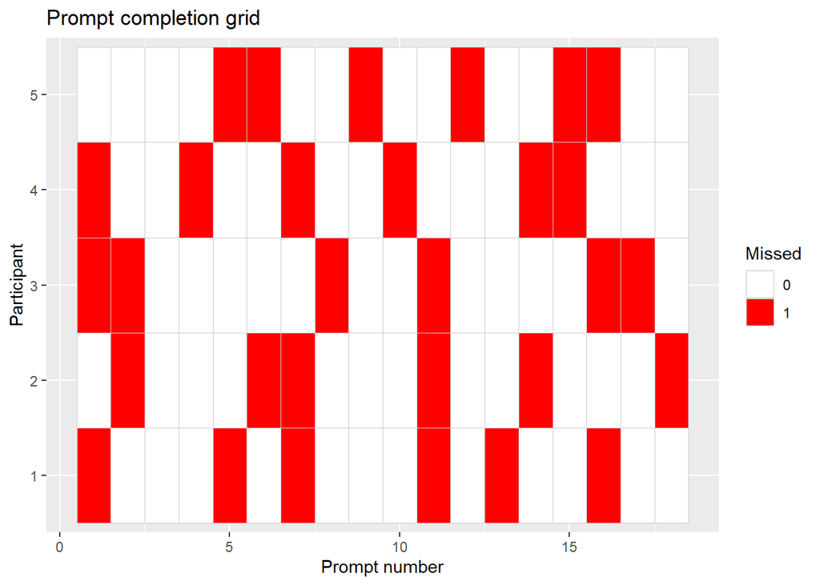

```r
gg <- ggplot(ema_df, aes(x = prompt_num, y = factor(id), fill = factor(missed_prompt))) +
  geom_tile(color = "gray80") +
  scale_fill_manual(values = c("0" = "white", "1" = "red"),
                    name = "Missed") +
  labs(title = "Prompt completion grid",
       x = "Prompt number", y = "Participant")
plot(gg)
```

# Part 6 Export Prepared Data

```r
save (ema_df, file="ema_prepared.rda")
```

# Part 7 Next Step

Proceed to **Step 2**: evaluate the utility of candidate auxiliary variables in predicting missingness using `ema_prepared.rda`.